# 토트넘-해리케인과-손흥민의-비교분석

해리 케인의 이적이 확정됐다. 손흥민이 그 자리를 메꿀 수 있을까?

Behind Numbers

2023-08-13

> 해리 케인의 이적으로 토트넘의 전력을 얼마나 악화될 것인가? 과연 손흥민 선수가 그 빈 자리를 채울 수 있을까? 해리 케인이 이적하면 토트넘의 득점력은 어떻게 달라질 것인가. 통계를 보며 생각해보자.

# 손흥민과 해리 케인

## 공통점

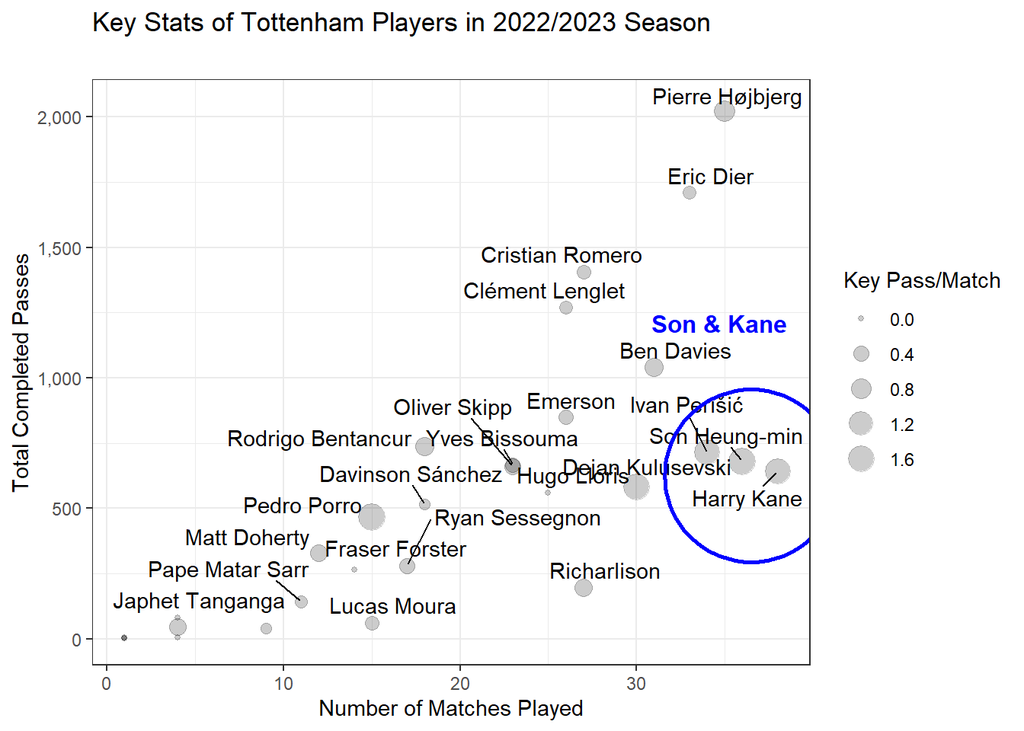

손흥민 선수는 2021/2022 시즌만큼의 활약은 아니지만 지난 시즌에서도 준수한 성적을 기록했다. 같은 대한민국 국민으로써 자랑스럽기 그지없다. 위 차트를 보면 손흥민과 해리 케인은 약 36경기 정도를 소화하며 650개 정도의 패스를 기록했다. 특히 두 선수는 높은 경기당 1.6개의 `Key Pass`를 기록했다. `Key Pass`는 슛팅으로 이어진 패스다. 슛팅으로 이어진 모든 패스가 좋은 패스는 아니지만, 많은 데이터가 쌓일수록 더 큰 의미를 갖는다. 한 두번의 패스는 우연히 좋은 슛팅으로 연결되기도 *하지만 결국 슛팅으로 연결되기 위해서는 위험지역으로 슛팅하기 좋게 패스하는 게 중요하기 때문이다.*

호이비에르는 무려 2천개가 넘는 패스를 2022/23 시즌 동안 기록했다. 공격에도 자주 가담하지만 기본적으로 포지션이 미드필더이기 때문에 `Key Pass`의 빈도는 적다. * * *

## 해리 케인과 손흥민의 차이점

### 경기당 Key Pass

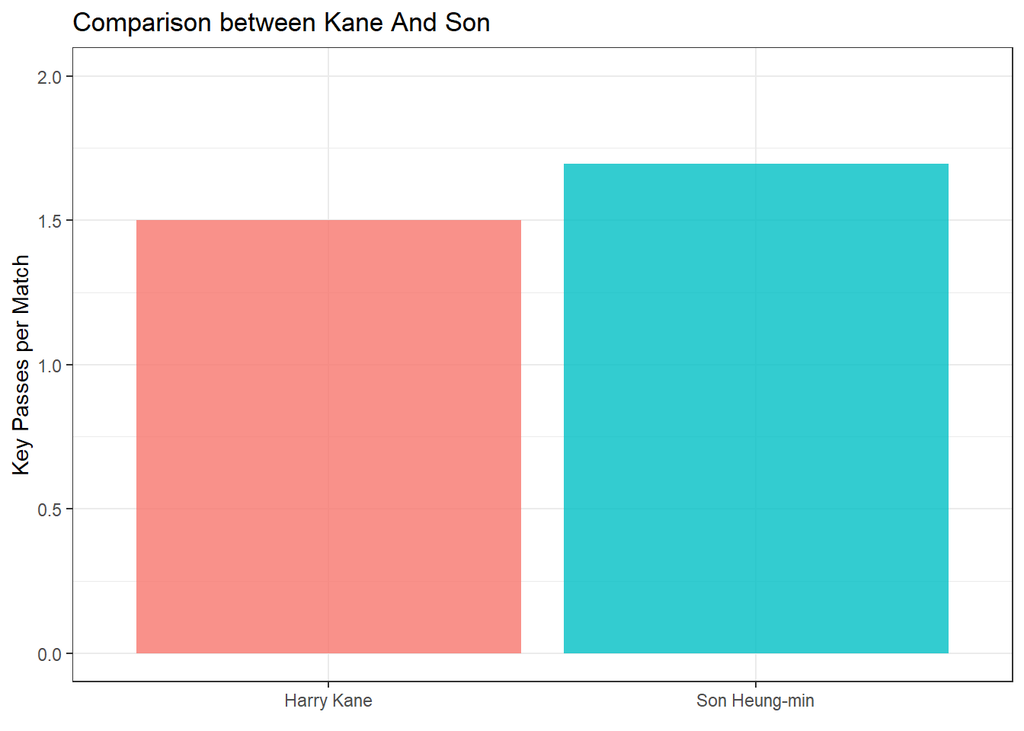

앞서 이야기했다시피 Key Pass의 경우 두 선수 모두 훌륭하다. 굳이 비교하자면 손흥민이 다소 높은 편이다. 경기를 보면 쉽게 알 수 있다. 손흥민은 케인보다 양질의 크로스를 올린다. 그리고 기본적인 활동 반경이 해리 케인이 조금 더 넓다. 손흥민은 주로 페널티 박스 근처나 페널티 박스 안에 머무르기 때문에 확률적으로 `Key Pass`를 할 가능성이 높은 것이다.

### Final Third로의 패스

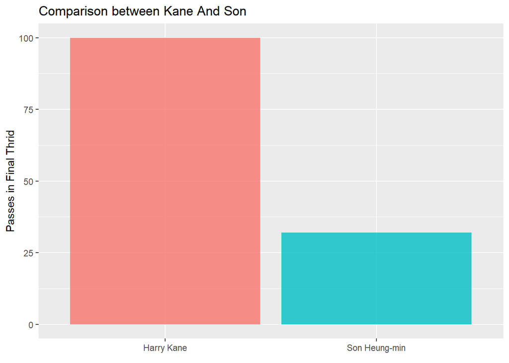

단순히 Key Pass를 비교하지 않고 전반적인 패스가 얼마나 공격적이었는가를 비교하면 이야기가 다르다. 위 표는 `Final Third`로 *성공적으로 연결된 패스*의 숫자다. 여기서 꽤 큰 차이가 난다. 이 부분은 사실 해리 케인이 압도적으로 우세하다. 손흥민이 주로 전방에 머물러 있었기 때문에 `Final Third`로 패스할 기회가 적었다는 걸 감안하더라도 차이가 너무 크다. 어쩌면 해리 케인은 기존 자원으로는 대체할 수 없는 선수인지도 모른다.

### Final Third로의 Carry

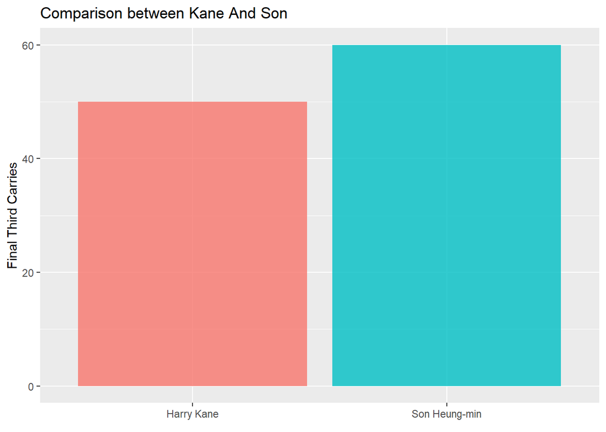

*Carry란 패스가 아닌, 드리블로 볼을 직접 운반하는 것을 말한다.* 경기장의 상대방 1/3 지점으로 볼을 직접 *성공적으로* 드리블한 횟수를 말한다. 손흥민은 빠른 발을 바탕으로 경기장 중앙부터 빠르게 앞으로 드리블 해 나가는 걸 볼 수 있다. 해리 케인도 마찬가지다. 좋은 피지컬을 바탕으로 볼을 빼앗기지 않고 전진시킨다. 큰 차이는 아니지만 손흥민이 이 부분에 있어서 다소 우세하다. 하지만 큰 차이가 아닌 것에 주목하자. 2022/23 시즌 동안의 수치로써 프리미어리그가 38경기인 것을 감안하면 경기당 0.25회의 차이에 불과하다.

## 두 선수의 가장 결정적인 차이는?

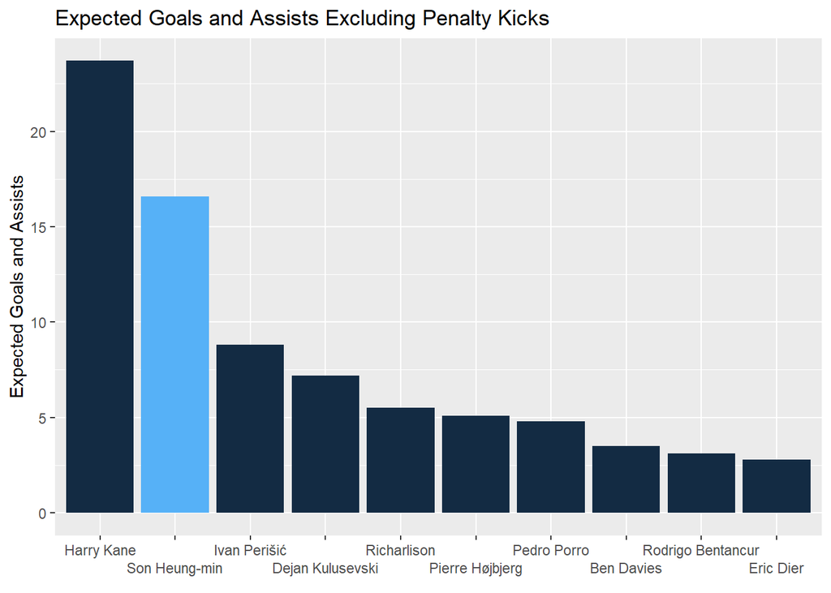

이제는 축구에서도 통계적인 분석이 주의를 끌고 있다. *그 중 가장 중요한 지표가 xG 이다.* xG 는 expected Goals의 약자다. `만약 정확히 같은 위치와 상황에서 100번의 슛을 했을 때 슛을 성공시킬 확률이 얼마인지를 나타내는 지표다.` 이 지표는 볼과 골대와의 거리, 가장 가까운 상대 선수와 볼과의 거리, 골대와 볼 사이에 위치한 선수의 수, 오른발, 왼발, 헤딩, 발리슛팅 외에도 여러가지 요소를 감안해서 분석한 수치다.

## 결론

과연 해리 케인이 없는 토트넘은 이번 시즌 좋은 성적을 거둘 수 있을까?